# Practice time!

# Logistic Regression in R

## A simple example

In this section, we will use the Social Networks Ads data, that we have previously seen when we studied svm’s.

We start loading the data set into R.

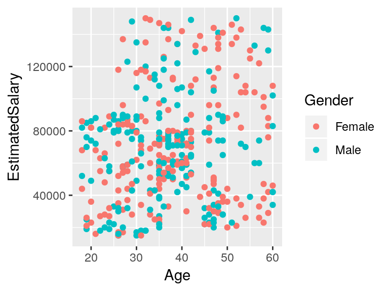

```r
load("source/Ads.RData")

library(ggplot2)
ggplot(data) + aes(x = Age, y = EstimatedSalary, color = Gender)+geom_point()
```

Remember, in logistic regression, we approximate $p$ in terms of the linear predictor
$$\eta = \beta_0 + \beta_1 X_1+ \beta_2 X_2 + \ldots \beta_p X_p.$$
The objective is to choose the optimal $\beta_0, \beta_1, \ldots \beta_p$ such that
$$R(\mathbf{\beta}) = \sum_{i=1}^{N} \log\left( 1 + \exp(\mathbf{x}_i^T \mathbf{\beta}) \right) - \sum_{i=1}^{N} y_i \mathbf{x}_i^T \mathbf{\beta}$$
is minimized. So, the model matrix $X$ should have 1’s in the first column, with $p+1$ columns, one for each variable.

What about categorical variables?

Categorical (factor) variables should be converted to dummy variables. Function `glm` automatically does that for us, but we can manually perform that conversion with function `model.matrix`.

```r
X = model.matrix(Purchased~., data)
head(X)
```

```
##          (Intercept) GenderMale Age EstimatedSalary
## 15624510           1          1  19           19000
## 15810944           1          1  35           20000
## 15668575           1          0  26           43000
## 15603246           1          0  27           57000
## 15804002           1          1  19           76000
## 15728773           1          1  27           58000
```

To estimate the $\beta$ parameter from the logistic regression model, we use the following syntax.

```r
fit.logit = glm(Purchased~., data = data, family = "binomial")
summary(fit.logit)
```

```
##
## Call:
## glm(formula = Purchased ~ ., family = "binomial", data = data)
##
## Deviance Residuals:
##     Min       1Q   Median       3Q      Max
## -2.9109  -0.5218  -0.1406   0.3662   2.4254
##
## Coefficients:
##                   Estimate Std. Error z value Pr(>|z|)
## (Intercept)     -1.278e+01  1.359e+00  -9.405  < 2e-16 ***
## GenderMale       3.338e-01  3.052e-01   1.094    0.274
## Age              2.370e-01  2.638e-02   8.984  < 2e-16 ***
## EstimatedSalary  3.644e-05  5.473e-06   6.659 2.77e-11 ***
## ---
## Signif. codes:  0 '***' 0.001 '**' 0.01 '*' 0.05 '.' 0.1 ' ' 1
##
## (Dispersion parameter for binomial family taken to be 1)
##
##     Null deviance: 521.57  on 399  degrees of freedom
## Residual deviance: 275.84  on 396  degrees of freedom
## AIC: 283.84
##
## Number of Fisher Scoring iterations: 6
```

Let’s perform some simple cross validation to evaluate the model.

```r
source("https://raw.githubusercontent.com/jlaria/dsclass/master/R/prop.split.R")

# Split the data
idx = prop.split(400, c(0.6, 0.4))
data.train = data[idx[[1]],]
data.validate = data[idx[[2]],]

# Train the model
fit.logit = glm(Purchased~., data.train, family = "binomial")
summary(fit.logit)
```

```
##
## Call:
## glm(formula = Purchased ~ ., family = "binomial", data = data.train)
##
## Deviance Residuals:
##     Min       1Q   Median       3Q      Max
## -2.7228  -0.6200  -0.1759   0.5208   1.8166
##
## Coefficients:
##                   Estimate Std. Error z value Pr(>|z|)
## (Intercept)     -1.080e+01  1.486e+00  -7.264 3.75e-13 ***
## GenderMale       6.961e-02  3.635e-01   0.191    0.848
## Age              2.035e-01  2.956e-02   6.885 5.76e-12 ***
## EstimatedSalary  2.975e-05  6.137e-06   4.849 1.24e-06 ***
## ---
## Signif. codes:  0 '***' 0.001 '**' 0.01 '*' 0.05 '.' 0.1 ' ' 1
##
## (Dispersion parameter for binomial family taken to be 1)
##
##     Null deviance: 315.44  on 239  degrees of freedom
## Residual deviance: 188.34  on 236  degrees of freedom
## AIC: 196.34
##
## Number of Fisher Scoring iterations: 6
```

```r
# Select variables
fit.logit = glm(Purchased~Age+EstimatedSalary, data.train, family = "binomial")
summary(fit.logit)
```

```
##
## Call:
## glm(formula = Purchased ~ Age + EstimatedSalary, family = "binomial",
##     data = data.train)
##
## Deviance Residuals:
##     Min       1Q   Median       3Q      Max
## -2.7323  -0.6295  -0.1756   0.5265   1.8329
##
## Coefficients:
##                   Estimate Std. Error z value Pr(>|z|)
## (Intercept)     -1.074e+01  1.459e+00  -7.363 1.80e-13 ***
## Age              2.032e-01  2.952e-02   6.885 5.76e-12 ***
## EstimatedSalary  2.966e-05  6.115e-06   4.849 1.24e-06 ***
## ---
## Signif. codes:  0 '***' 0.001 '**' 0.01 '*' 0.05 '.' 0.1 ' ' 1
##
## (Dispersion parameter for binomial family taken to be 1)
##
##     Null deviance: 315.44  on 239  degrees of freedom
## Residual deviance: 188.38  on 237  degrees of freedom
## AIC: 194.38
##
## Number of Fisher Scoring iterations: 6
```

```r
# Validate it
pred = predict(fit.logit, newdata = data.validate, type = "response")
y_pred = ifelse(pred>0.7, "yes", "no")
t = table(y_pred, data.validate$Purchased); t
```

```
##
## y_pred  no yes
##    no  103  20
##    yes   2  35
```

```r
ccr = sum(diag(t))/sum(t); ccr
```

```
## [1] 0.8625
```

## Suicides Data set

We start loading the data set.

```r
load("source/data_suic.RData")
```

### A first approximation

Let’s fit a logistic model on this data.

```r
fit.logit = glm(INT_ACTUAL~., data, family = "binomial")
summary(fit.logit)
```

```
##
## Call:
## glm(formula = INT_ACTUAL ~ ., family = "binomial", data = data)
##
## Deviance Residuals:
##     Min       1Q   Median       3Q      Max
## -3.3646  -0.4089  -0.1983   0.3340   2.9062
##
## Coefficients:
##             Estimate Std. Error z value Pr(>|z|)
## (Intercept) -1.11708    0.96205  -1.161 0.245583
## ipd12       -1.01693    0.31045  -3.276 0.001054 **
## ipd22       -0.13973    0.35839  -0.390 0.696623
## ipd32       -0.10136    0.25677  -0.395 0.693034
## ipd42        1.06291    0.28907   3.677 0.000236 ***
## ipd52        0.13898    0.27253   0.510 0.610070
## ipd62       -0.15463    0.31034  -0.498 0.618291
## ipd72       -0.12962    0.54709  -0.237 0.812722
## ipd82       -0.05329    0.28024  -0.190 0.849195
## ipd92        0.02728    0.30884   0.088 0.929608
## ipd102      -0.04977    0.26036  -0.191 0.848400
## ipd112       0.58106    0.33031   1.759 0.078559 .
## ipd122      -0.10653    0.35021  -0.304 0.760976
## ipd132       0.36418    0.32629   1.116 0.264366
## ipd142       0.49276    0.31759   1.552 0.120775
## ipd152      -0.84657    0.29991  -2.823 0.004762 **
## ipd162      -0.44811    0.33143  -1.352 0.176358
## ipd172       0.10854    0.28620   0.379 0.704505
## ipd182       0.55781    0.60593   0.921 0.357266
## ipd192      -0.18180    0.25602  -0.710 0.477633
## ipd202      -0.13987    0.29828  -0.469 0.639136
## ipd212       0.13916    0.28556   0.487 0.626027
## ipd222      -1.16940    0.44181  -2.647 0.008125 **
## ipd232       0.19047    0.28146   0.677 0.498569
## ipd242      -0.44620    0.34753  -1.284 0.199164
## ipd252      -1.89873    0.25249  -7.520 5.47e-14 ***
## ipd262       0.02258    0.32827   0.069 0.945171
## ipd272       0.36497    0.31435   1.161 0.245642
## ipd282       0.20108    0.33021   0.609 0.542569
## ipd292       0.23773    0.35845   0.663 0.507201
```

[output cut: 43 more lines]

```
## ipd732       0.19154    0.27724   0.691 0.489644
## ipd742       0.33883    0.35862   0.945 0.344760
## ipd752       0.76970    0.35101   2.193 0.028321 *
## ipd762      -0.06114    0.27925  -0.219 0.826696
## ipd772      -0.19766    0.32209  -0.614 0.539415
## ---
## Signif. codes:  0 '***' 0.001 '**' 0.01 '*' 0.05 '.' 0.1 ' ' 1
##
## (Dispersion parameter for binomial family taken to be 1)
##
##     Null deviance: 1064.81  on 827  degrees of freedom
## Residual deviance:  515.76  on 750  degrees of freedom
## AIC: 671.76
##
## Number of Fisher Scoring iterations: 6
```

In this first approximation, we will avoid variable selection.

```r
pred = predict(fit.logit, newdata = data, type="response")
y_pred = ifelse(pred>0.5, 1, 0)
t = table(y_pred, data$INT_ACTUAL); t
```

```
##
## y_pred   0   1
##      0 500  63
##      1  44 221
```

```r
ccr = sum(diag(t))/sum(t); ccr
```

```
## [1] 0.8707729
```

We got as high as 87% of correct classification rate. Of course, this is the trainig data, so, we will probably overfit a lot.

### Fitting a better model

Based on the variables that we observed as significannt in the previous analysis, we can fit better models.

```r
load("source/data_suic.RData")
# Filter significant variables
fit.logit = glm(INT_ACTUAL~., data, family = "binomial")
s = summary(fit.logit)
predictors = (s$coefficients[,4] < 0.05)[-1]

data = data[, c(predictors,T)]

# Split the data set
source("https://raw.githubusercontent.com/jlaria/dsclass/master/R/prop.split.R")
idx = prop.split(828, p=c(0.6,0.4))
train = data[idx[[1]], ]
validate = data[idx[[1]],]

# Fit the model
fit.logit = glm(INT_ACTUAL~., train, family = "binomial")
summary(fit.logit)
```

```
##
## Call:
## glm(formula = INT_ACTUAL ~ ., family = "binomial", data = train)
##
## Deviance Residuals:
##     Min       1Q   Median       3Q      Max
## -2.8068  -0.4169  -0.2432   0.4296   2.7617
##
## Coefficients:
##             Estimate Std. Error z value Pr(>|z|)
## (Intercept)  0.02805    0.47484   0.059 0.952889
## ipd12       -1.03128    0.32197  -3.203 0.001360 **
## ipd42        0.44025    0.31171   1.412 0.157838
## ipd152      -0.65641    0.30753  -2.134 0.032804 *
## ipd222      -1.01910    0.41332  -2.466 0.013676 *
## ipd252      -1.54679    0.28755  -5.379 7.48e-08 ***
## ipd332       0.25971    0.31514   0.824 0.409889
## ipd362       0.15477    0.33469   0.462 0.643766
## ipd402       1.65003    0.34068   4.843 1.28e-06 ***
## ipd432       1.05429    0.30867   3.416 0.000636 ***
## ipd462      -0.73950    0.32544  -2.272 0.023069 *
## ipd602       0.69743    0.34521   2.020 0.043355 *
## ipd752       0.63403    0.37457   1.693 0.090509 .
## ---
## Signif. codes:  0 '***' 0.001 '**' 0.01 '*' 0.05 '.' 0.1 ' ' 1
##
## (Dispersion parameter for binomial family taken to be 1)
##
##     Null deviance: 644.85  on 496  degrees of freedom
## Residual deviance: 333.47  on 484  degrees of freedom
## AIC: 359.47
##
## Number of Fisher Scoring iterations: 5
```

```r
# Predict
pred = predict(fit.logit, newdata = validate, type = "response")
y_pred = ifelse(pred>0.5, 1, 0)
t = table(y_pred, validate$INT_ACTUAL); t
```

```
##
## y_pred   0   1
##      0 289  40
##      1  33 135
```

```r
ccr = sum(diag(t))/sum(t); ccr
```

```
## [1] 0.8531187
```

```r
tpr = t[2,2]/sum(t[,2]); tpr
```

```
## [1] 0.7714286
```

### Movig the cut-point

```r
y_pred = ifelse(pred>0.35, 1, 0)
t = table(y_pred, validate$INT_ACTUAL); t
```

```
##
## y_pred   0   1
##      0 274  25
##      1  48 150
```

```r
ccr = sum(diag(t))/sum(t); ccr
```

```
## [1] 0.8531187
```

```r
tpr = t[2,2]/sum(t[,2]); tpr
```

```
## [1] 0.8571429
```

```r
y_pred = ifelse(pred>0.15, 1, 0)
t = table(y_pred, validate$INT_ACTUAL); t
```

```
##
## y_pred   0   1
##      0 232   9
##      1  90 166
```

```r
ccr = sum(diag(t))/sum(t); ccr
```

```
## [1] 0.8008048
```

```r
tpr = t[2,2]/sum(t[,2]); tpr
```

```
## [1] 0.9485714
```

```r
y_pred = ifelse(pred>0.05, 1, 0)
t = table(y_pred, validate$INT_ACTUAL); t
```

```
##
## y_pred   0   1
##      0 139   1
##      1 183 174
```

```r
ccr = sum(diag(t))/sum(t); ccr
```

```
## [1] 0.6297787
```

```r
tpr = t[2,2]/sum(t[,2]); tpr
```

```
## [1] 0.9942857
```

### Computing the ROC curve

```r
library(ROCR)
```

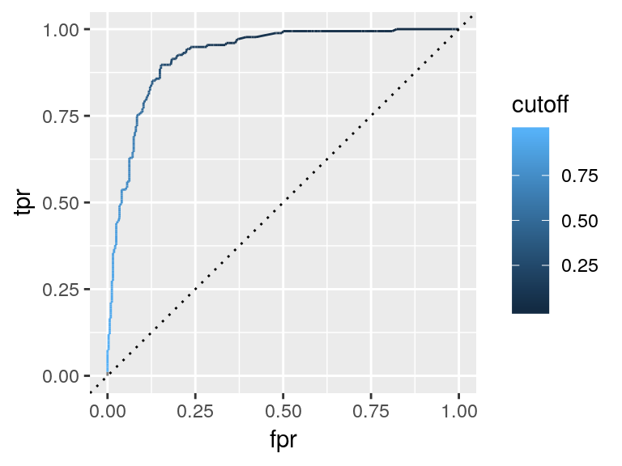

```r
pred = prediction(pred, validate$INT_ACTUAL)
perf = performance(pred, "tpr", "fpr")

perf_df = data.frame(
x = perf@x.values,
y = perf@y.values,
cutoff = perf@alpha.values
)

colnames(perf_df) = c("fpr", "tpr", "cutoff")
ggplot(perf_df)+
aes(x = fpr, y = tpr, color = cutoff)+
geom_line()+
geom_abline(intercept = 0, slope = 1, lty = "dotted")
```

```r
perf = performance(pred, "acc")
max(perf@y.values[[1]])
```

```
## [1] 0.8651911
```

```r
optimal.cutoff = perf@x.values[[1]][which.max(perf@y.values[[1]])]
optimal.cutoff
```

```
##       929
## 0.3801287
```